# Diwali Sales Analysis

```python
# Import Python Libraries
import numpy as np
import pandas as pd
import matplotlib.pyplot as plt
import seaborn as sns
```

```python
# import csv file
g = pd.read_csv('Diwali Sales Data.csv', encoding= 'unicode_escape')
```

```python
g.head(15)
```

|  | User_ID | Cust_name | Product_ID | Gender | Age Group | Age | Marital_Status | State | Zone | Occupation | Product_Category | Orders | Amount | Status | unnamed1 |
| --- | --- | --- | --- | --- | --- | --- | --- | --- | --- | --- | --- | --- | --- | --- | --- |
| 0 | 1002903 | Sanskriti | P00125942 | F | 26-35 | 28 | 0 | Maharashtra | Western | Healthcare | Auto | 1 | 23952.00 | NaN | NaN |
| 1 | 1000732 | Kartik | P00110942 | F | 26-35 | 35 | 1 | Andhra Pradesh | Southern | Govt | Auto | 3 | 23934.00 | NaN | NaN |
| 2 | 1001990 | Bindu | P00118542 | F | 26-35 | 35 | 1 | Uttar Pradesh | Central | Automobile | Auto | 3 | 23924.00 | NaN | NaN |
| 3 | 1001425 | Sudevi | P00237842 | M | 0-17 | 16 | 0 | Karnataka | Southern | Construction | Auto | 2 | 23912.00 | NaN | NaN |
| 4 | 1000588 | Joni | P00057942 | M | 26-35 | 28 | 1 | Gujarat | Western | Food Processing | Auto | 2 | 23877.00 | NaN | NaN |
| 5 | 1000588 | Joni | P00057942 | M | 26-35 | 28 | 1 | Himachal Pradesh | Northern | Food Processing | Auto | 1 | 23877.00 | NaN | NaN |
| 6 | 1001132 | Balk | P00018042 | F | 18-25 | 25 | 1 | Uttar Pradesh | Central | Lawyer | Auto | 4 | 23841.00 | NaN | NaN |
| 7 | 1002092 | Shivangi | P00273442 | F | 55+ | 61 | 0 | Maharashtra | Western | IT Sector | Auto | 1 | NaN | NaN | NaN |
| 8 | 1003224 | Kushal | P00205642 | M | 26-35 | 35 | 0 | Uttar Pradesh | Central | Govt | Auto | 2 | 23809.00 | NaN | NaN |
| 9 | 1003650 | Ginny | P00031142 | F | 26-35 | 26 | 1 | Andhra Pradesh | Southern | Media | Auto | 4 | 23799.99 | NaN | NaN |
| 10 | 1003829 | Harshita | P00200842 | M | 26-35 | 34 | 0 | Delhi | Central | Banking | Auto | 1 | 23770.00 | NaN | NaN |
| 11 | 1000214 | Kargatis | P00119142 | F | 18-25 | 20 | 0 | Andhra Pradesh | Southern | Retail | Auto | 2 | 23752.00 | NaN | NaN |
| 12 | 1004035 | Elijah | P00080342 | F | 18-25 | 20 | 1 | Andhra Pradesh | Southern | IT Sector | Auto | 2 | 23730.00 | NaN | NaN |
| 13 | 1001680 | Vasudev | P00324942 | M | 26-35 | 26 | 1 | Andhra Pradesh | Southern | Automobile | Auto | 4 | 23718.00 | NaN | NaN |
| 14 | 1003858 | Cano | P00293742 | M | 46-50 | 46 | 1 | Madhya Pradesh | Central | Hospitality | Auto | 3 | NaN | NaN | NaN |

```python
g.tail(20)
```

|  | User_ID | Cust_name | Product_ID | Gender | Age Group | Age | Marital_Status | State | Zone | Occupation | Product_Category | Orders | Amount | Status | unnamed1 |
| --- | --- | --- | --- | --- | --- | --- | --- | --- | --- | --- | --- | --- | --- | --- | --- |
| 11231 | 1003557 | Craven | P00046142 | F | 18-25 | 20 | 0 | Delhi | Central | Healthcare | Office | 3 | 563.0 | NaN | NaN |
| 11232 | 1001360 | Darrin | P00112642 | F | 26-35 | 27 | 1 | Delhi | Central | Chemical | Office | 3 | 563.0 | NaN | NaN |
| 11233 | 1002106 | Luke | P00164342 | M | 18-25 | 19 | 0 | Maharashtra | Western | Agriculture | Office | 1 | 563.0 | NaN | NaN |
| 11234 | 1001628 | Sandeep | P00226342 | F | 18-25 | 21 | 0 | Delhi | Central | Aviation | Office | 3 | 562.0 | NaN | NaN |
| 11235 | 1001248 | Calhoun | P00255842 | M | 36-45 | 39 | 0 | Andhra Pradesh | Southern | Healthcare | Office | 3 | 560.0 | NaN | NaN |
| 11236 | 1002168 | Hightower | P00145842 | M | 0-17 | 17 | 1 | Himachal Pradesh | Northern | Agriculture | Office | 4 | 560.0 | NaN | NaN |
| 11237 | 1000687 | Neola | P00181542 | M | 26-35 | 29 | 1 | Haryana | Northern | Media | Office | 2 | 557.0 | NaN | NaN |
| 11238 | 1002718 | Abhishek | P00003442 | M | 26-35 | 28 | 0 | Karnataka | Southern | IT Sector | Office | 1 | 555.0 | NaN | NaN |
| 11239 | 1000802 | Marley | P00245642 | F | 26-35 | 33 | 0 | Delhi | Central | Healthcare | Office | 1 | 407.0 | NaN | NaN |
| 11240 | 1001425 | Sudevi | P00044742 | F | 0-17 | 12 | 0 | Delhi | Central | IT Sector | Veterinary | 1 | 396.0 | NaN | NaN |
| 11241 | 1003032 | Matthias | P00058042 | F | 26-35 | 33 | 0 | Delhi | Central | Hospitality | Office | 3 | 384.0 | NaN | NaN |
| 11242 | 1004344 | Hildebrand | P00185442 | F | 26-35 | 27 | 1 | Delhi | Central | Healthcare | Office | 2 | 382.0 | NaN | NaN |
| 11243 | 1005446 | Sheetal | P00297742 | M | 51-55 | 53 | 0 | Gujarat | Western | Healthcare | Office | 1 | 382.0 | NaN | NaN |
| 11244 | 1005446 | Sheetal | P00297742 | M | 51-55 | 53 | 0 | Madhya Pradesh | Central | Healthcare | Office | 2 | 382.0 | NaN | NaN |
| 11245 | 1004140 | Bertelson | P00057442 | F | 26-35 | 31 | 1 | Delhi | Central | Aviation | Office | 2 | 381.0 | NaN | NaN |
| 11246 | 1000695 | Manning | P00296942 | M | 18-25 | 19 | 1 | Maharashtra | Western | Chemical | Office | 4 | 370.0 | NaN | NaN |
| 11247 | 1004089 | Reichenbach | P00171342 | M | 26-35 | 33 | 0 | Haryana | Northern | Healthcare | Veterinary | 3 | 367.0 | NaN | NaN |
| 11248 | 1001209 | Oshin | P00201342 | F | 36-45 | 40 | 0 | Madhya Pradesh | Central | Textile | Office | 4 | 213.0 | NaN | NaN |
| 11249 | 1004023 | Noonan | P00059442 | M | 36-45 | 37 | 0 | Karnataka | Southern | Agriculture | Office | 3 | 206.0 | NaN | NaN |
| 11250 | 1002744 | Brumley | P00281742 | F | 18-25 | 19 | 0 | Maharashtra | Western | Healthcare | Office | 3 | 188.0 | NaN | NaN |

```python
g.shape
```

```
(11251, 15)
```

```python
g.size
```

```
168765
```

```python
g.describe().T
```

|  | count | mean | std | min | 25% | 50% | 75% | max |
| --- | --- | --- | --- | --- | --- | --- | --- | --- |
| User_ID | 11251.0 | 1.003004e+06 | 1716.125402 | 1000001.0 | 1001492.0 | 1003065.0 | 1004430.0 | 1006040.0 |
| Age | 11251.0 | 3.542121e+01 | 12.754122 | 12.0 | 27.0 | 33.0 | 43.0 | 92.0 |
| Marital_Status | 11251.0 | 4.203182e-01 | 0.493632 | 0.0 | 0.0 | 0.0 | 1.0 | 1.0 |
| Orders | 11251.0 | 2.489290e+00 | 1.115047 | 1.0 | 1.5 | 2.0 | 3.0 | 4.0 |
| Amount | 11239.0 | 9.453611e+03 | 5222.355869 | 188.0 | 5443.0 | 8109.0 | 12675.0 | 23952.0 |
| Status | 0.0 | NaN | NaN | NaN | NaN | NaN | NaN | NaN |
| unnamed1 | 0.0 | NaN | NaN | NaN | NaN | NaN | NaN | NaN |

```python
g.columns
```

```
Index(['User_ID', 'Cust_name', 'Product_ID', 'Gender', 'Age Group', 'Age',
       'Marital_Status', 'State', 'Zone', 'Occupation', 'Product_Category',
       'Orders', 'Amount', 'Status', 'unnamed1'],
      dtype='object')
```

```python
g.info()
```

```
<class 'pandas.core.frame.DataFrame'>
RangeIndex: 11251 entries, 0 to 11250
Data columns (total 15 columns):
 #   Column            Non-Null Count  Dtype
---  ------            --------------  -----
 0   User_ID           11251 non-null  int64
 1   Cust_name         11251 non-null  object
 2   Product_ID        11251 non-null  object
 3   Gender            11251 non-null  object
 4   Age Group         11251 non-null  object
 5   Age               11251 non-null  int64
 6   Marital_Status    11251 non-null  int64
 7   State             11251 non-null  object
 8   Zone              11251 non-null  object
 9   Occupation        11251 non-null  object
 10  Product_Category  11251 non-null  object
 11  Orders            11251 non-null  int64
 12  Amount            11239 non-null  float64
 13  Status            0 non-null      float64
 14  unnamed1          0 non-null      float64
dtypes: float64(3), int64(4), object(8)
memory usage: 1.3+ MB
```

```python
# Drop Blank Column
g.drop(["Status","unnamed1"],axis=1,inplace=True)
```

```python
# Checking Null Value
g.isnull().sum()
```

```
User_ID              0
Cust_name            0
Product_ID           0
Gender               0
Age Group            0
Age                  0
Marital_Status       0
State                0
Zone                 0
Occupation           0
Product_Category     0
Orders               0
Amount              12
dtype: int64
```

```python
# Drop Null Value
g.dropna(inplace=True)
```

```python
# Distinct Counts Of Gender
g["Gender"].value_counts(normalize=True)*100
```

```
Gender
F    69.685915
M    30.314085
Name: proportion, dtype: float64
```

```python
# Checking Data Type
g.dtypes
```

```
User_ID               int64
Cust_name            object
Product_ID           object
Gender               object
Age Group            object
Age                   int64
Marital_Status        int64
State                object
Zone                 object
Occupation           object
Product_Category     object
Orders                int64
Amount              float64
dtype: object
```

```python
g["Amount"]=g["Amount"].astype("int")
```

```python
g["Amount"].dtypes
```

```
dtype('int32')
```

```python
#rename column
g.rename(columns= {'Marital_Status':'Shaadi'})
```

|  | User_ID | Cust_name | Product_ID | Gender | Age Group | Age | Shaadi | State | Zone | Occupation | Product_Category | Orders | Amount |
| --- | --- | --- | --- | --- | --- | --- | --- | --- | --- | --- | --- | --- | --- |
| 0 | 1002903 | Sanskriti | P00125942 | F | 26-35 | 28 | 0 | Maharashtra | Western | Healthcare | Auto | 1 | 23952 |
| 1 | 1000732 | Kartik | P00110942 | F | 26-35 | 35 | 1 | Andhra Pradesh | Southern | Govt | Auto | 3 | 23934 |
| 2 | 1001990 | Bindu | P00118542 | F | 26-35 | 35 | 1 | Uttar Pradesh | Central | Automobile | Auto | 3 | 23924 |
| 3 | 1001425 | Sudevi | P00237842 | M | 0-17 | 16 | 0 | Karnataka | Southern | Construction | Auto | 2 | 23912 |
| 4 | 1000588 | Joni | P00057942 | M | 26-35 | 28 | 1 | Gujarat | Western | Food Processing | Auto | 2 | 23877 |
| ... | ... | ... | ... | ... | ... | ... | ... | ... | ... | ... | ... | ... | ... |
| 11246 | 1000695 | Manning | P00296942 | M | 18-25 | 19 | 1 | Maharashtra | Western | Chemical | Office | 4 | 370 |
| 11247 | 1004089 | Reichenbach | P00171342 | M | 26-35 | 33 | 0 | Haryana | Northern | Healthcare | Veterinary | 3 | 367 |
| 11248 | 1001209 | Oshin | P00201342 | F | 36-45 | 40 | 0 | Madhya Pradesh | Central | Textile | Office | 4 | 213 |
| 11249 | 1004023 | Noonan | P00059442 | M | 36-45 | 37 | 0 | Karnataka | Southern | Agriculture | Office | 3 | 206 |
| 11250 | 1002744 | Brumley | P00281742 | F | 18-25 | 19 | 0 | Maharashtra | Western | Healthcare | Office | 3 | 188 |

11239 rows × 13 columns

```python
# Description of data (count,mean,std,etc)
g.describe()
```

|  | User_ID | Age | Marital_Status | Orders | Amount |
| --- | --- | --- | --- | --- | --- |
| count | 1.123900e+04 | 11239.000000 | 11239.000000 | 11239.000000 | 11239.000000 |
| mean | 1.003004e+06 | 35.410357 | 0.420055 | 2.489634 | 9453.610553 |
| std | 1.716039e+03 | 12.753866 | 0.493589 | 1.114967 | 5222.355168 |
| min | 1.000001e+06 | 12.000000 | 0.000000 | 1.000000 | 188.000000 |
| 25% | 1.001492e+06 | 27.000000 | 0.000000 | 2.000000 | 5443.000000 |
| 50% | 1.003064e+06 | 33.000000 | 0.000000 | 2.000000 | 8109.000000 |
| 75% | 1.004426e+06 | 43.000000 | 1.000000 | 3.000000 | 12675.000000 |
| max | 1.006040e+06 | 92.000000 | 1.000000 | 4.000000 | 23952.000000 |

```python
# Describing Specific Columns
g[["Age","Amount","Orders"]].describe().T
```

|  | count | mean | std | min | 25% | 50% | 75% | max |
| --- | --- | --- | --- | --- | --- | --- | --- | --- |
| Age | 11239.0 | 35.410357 | 12.753866 | 12.0 | 27.0 | 33.0 | 43.0 | 92.0 |
| Amount | 11239.0 | 9453.610553 | 5222.355168 | 188.0 | 5443.0 | 8109.0 | 12675.0 | 23952.0 |
| Orders | 11239.0 | 2.489634 | 1.114967 | 1.0 | 2.0 | 2.0 | 3.0 | 4.0 |

## Exploratory Data Analysis

# Gender

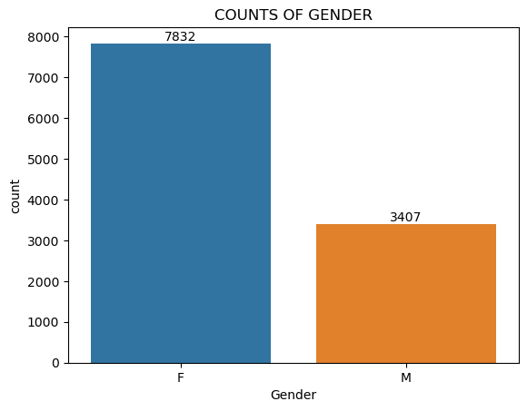

```python
# Plotting Bar Chart For Gender And Its Counts
k=sns.countplot(x="Gender",data=g)
for bars in k.containers:
    k.bar_label(bars)
plt.title("COUNTS OF GENDER")
```

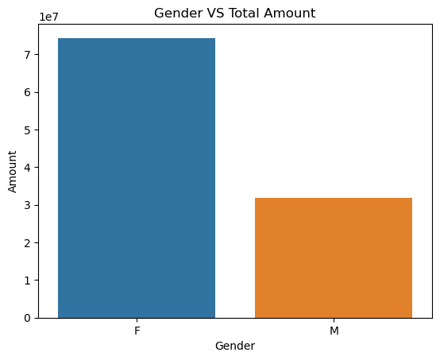

```python
# plotting a bar chart for gender vs total amount

sales_gen = g.groupby(['Gender'], as_index=False)['Amount'].sum().sort_values(by='Amount', ascending=False)

sns.barplot(x = 'Gender',y= 'Amount' ,data = sales_gen)
plt.title("Gender VS Total Amount")
```

From above grap we can see most of the buyers are females and purchaching rate of females are greater than mens

# Age

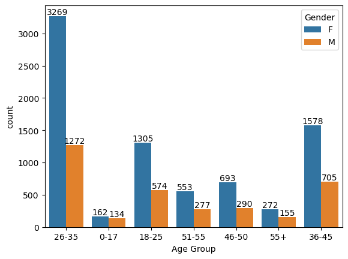

```python
ax = sns.countplot(data = g, x = 'Age Group', hue = 'Gender')

for bars in ax.containers:
    ax.bar_label(bars)
```

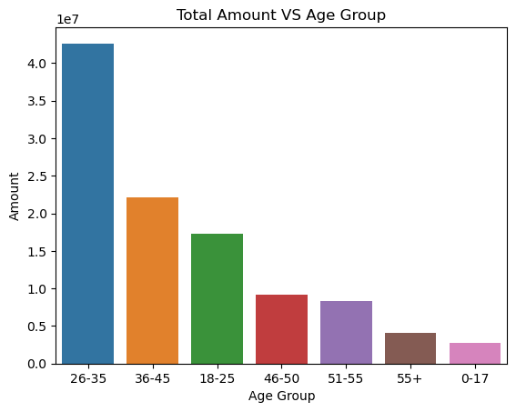

```python
# Total Amount vs Age Group
sales_age = g.groupby(['Age Group'], as_index=False)['Amount'].sum().sort_values(by='Amount', ascending=False)

sns.barplot(x = 'Age Group',y= 'Amount' ,data = sales_age)
plt.title("Total Amount VS Age Group")
```

From above graph we can see the most of the buyers are the age group between 26-35 years

# State

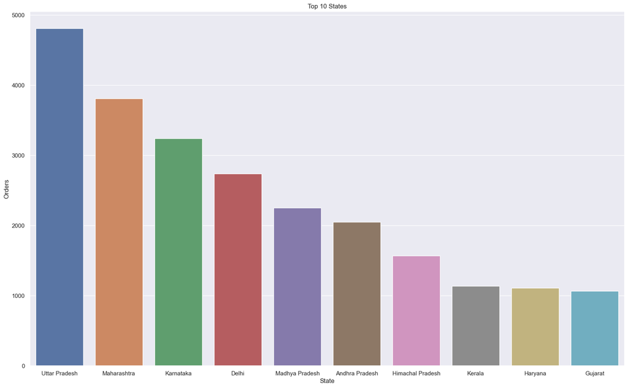

```python
# total number of orders from top 10 states

sales_state = g.groupby(['State'], as_index=False)['Orders'].sum().sort_values(by='Orders', ascending=False).head(10)

sns.set(rc={'figure.figsize':(20,12)})
sns.barplot(data = sales_state, x = 'State',y= 'Orders')
plt.title("Top 10 States")
```

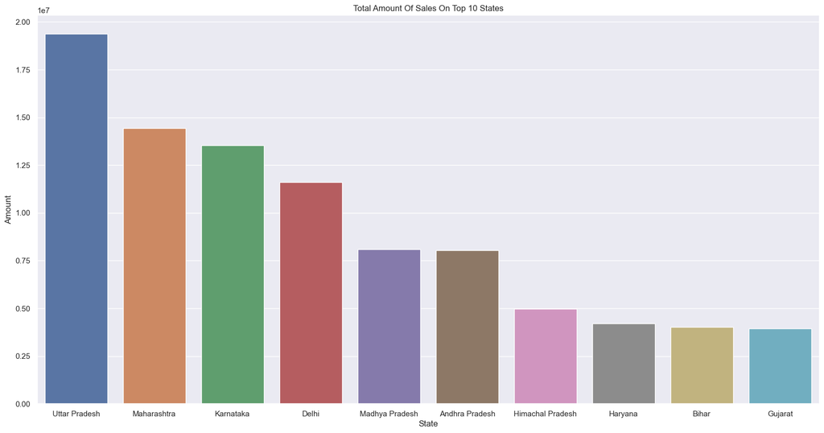

```python
# total amount/sales from top 10 states

sales_state = g.groupby(['State'], as_index=False)['Amount'].sum().sort_values(by='Amount', ascending=False).head(10)

sns.set(rc={'figure.figsize':(20,10)})
sns.barplot(data = sales_state, x = 'State',y= 'Amount')
plt.title("Total Amount Of Sales On Top 10 States")
```

from above graphs we can see the most of the orders and total sales/amount are from uttar pradesh,maharashtra,karnataka respectively.

# Marital Status

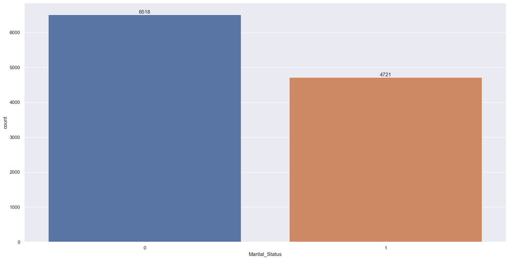

```python
ax = sns.countplot(data = g, x = 'Marital_Status')

sns.set(rc={'figure.figsize':(7,5)})
for bars in ax.containers:
    ax.bar_label(bars)
```

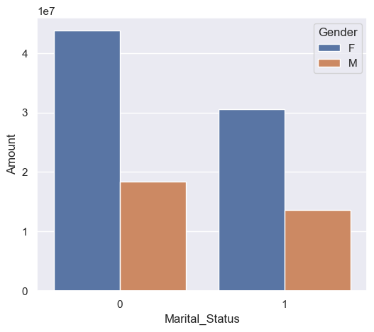

```python
sales_state = g.groupby(['Marital_Status', 'Gender'], as_index=False)['Amount'].sum().sort_values(by='Amount', ascending=False)

sns.set(rc={'figure.figsize':(6,5)})
sns.barplot(data = sales_state, x = 'Marital_Status',y= 'Amount', hue='Gender')
```

# Occupation

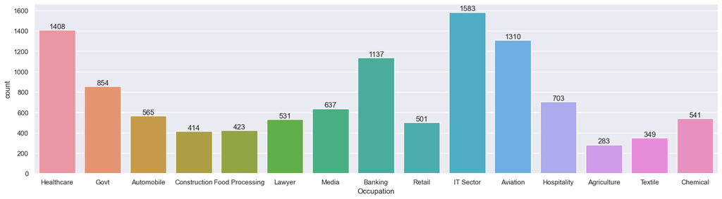

```python
sns.set(rc={'figure.figsize':(20,5)})
ax = sns.countplot(data = g, x = 'Occupation')

for bars in ax.containers:
    ax.bar_label(bars)
```

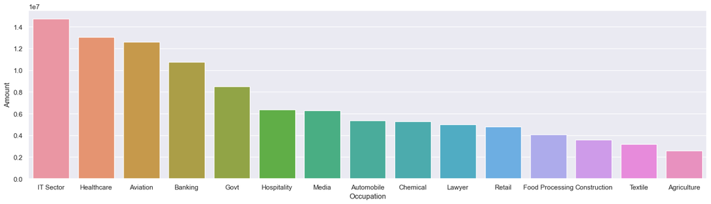

```python
sales_state = g.groupby(['Occupation'], as_index=False)['Amount'].sum().sort_values(by='Amount', ascending=False)

sns.set(rc={'figure.figsize':(20,5)})
sns.barplot(data = sales_state, x = 'Occupation',y= 'Amount')
```

From above graph we have see that the most of the buyers are working in IT,Healthcare,Aviation Sector